# Analise Lab6

Diego Ernesto

No documento a seguir irmos nos aprofundar na natureza dos dados de compra e de clicks cedido pela YooChoose para a competicao RecSys Challenge 2015. Primeiro vamos olhar o arquivo de como se comporta as compras dos clientes.

Vamos começar por um histograma do horario de compra dos clientes:

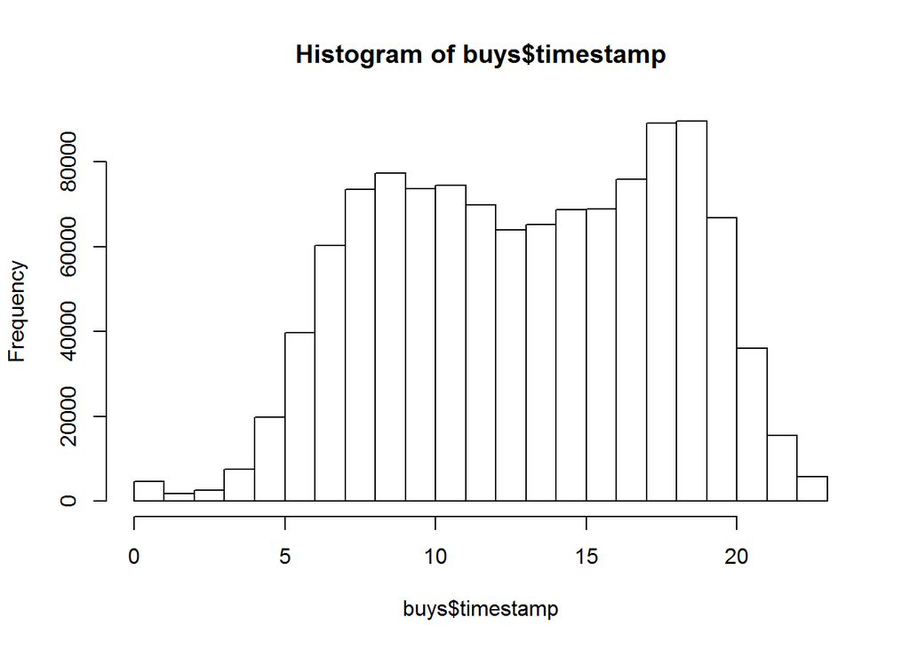

É simples perceber que das 7 da manha as 7 da noite é o periodo principal de compras, tendo como destaque 5 e 6 da tarde como hora mais propença a compras.

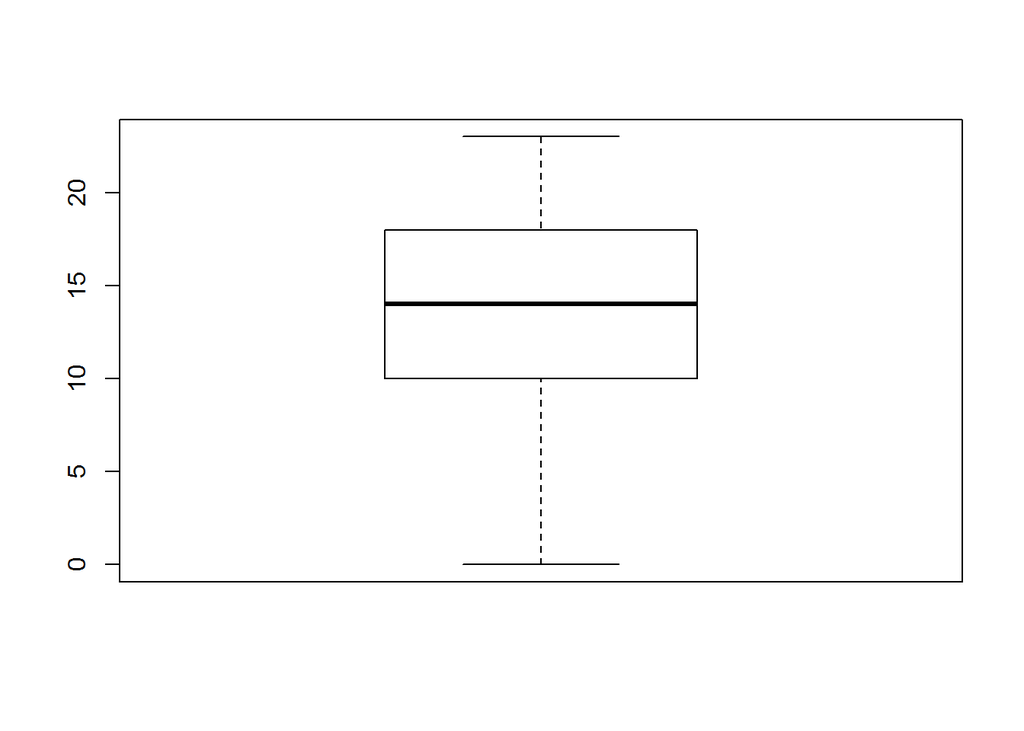

```
##    Min. 1st Qu.  Median    Mean 3rd Qu.    Max.
##    0.00   10.00   14.00   13.49   18.00   23.00
```

Agora analisando o preço gasto nas compras (retiradas as entradas com 0 como preço), temos:

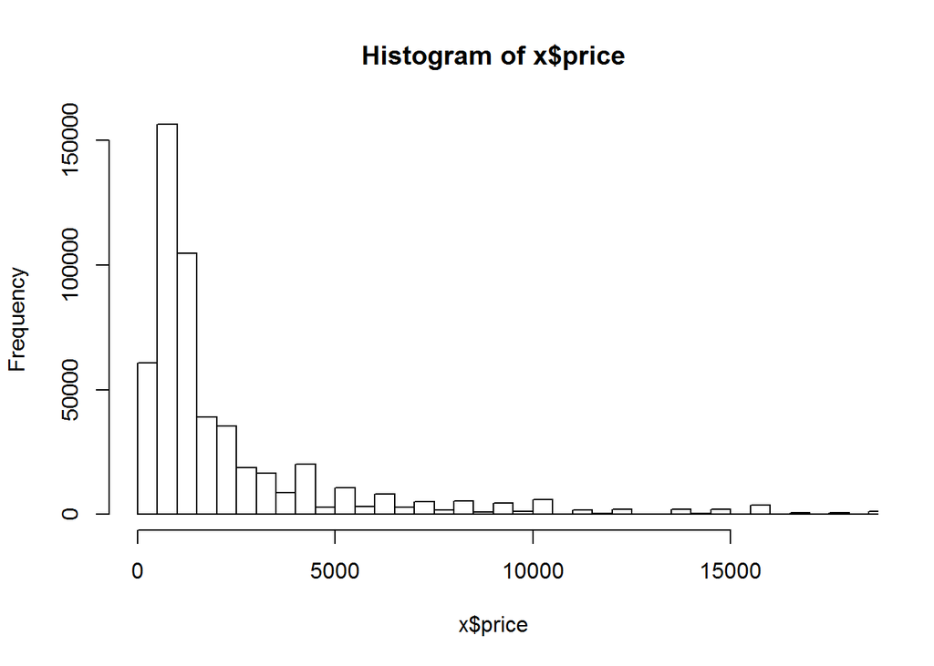

Já podemos ver de cara uma distribuicao assimetrica a direita, tambem podemos ver que quase todos os items vendidos custam menos de 6000.

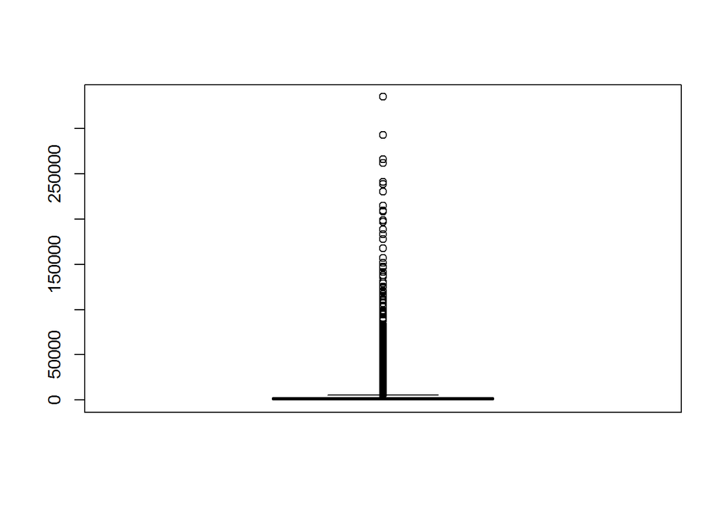

Vemos no primeiro plot do Boxplot que temos muitos outliers fora da maior concentraçao de dados, onde itens chegaram a custar ate mais que 250000.

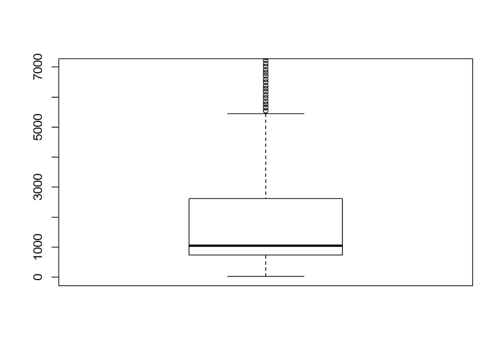

```
##    Min. 1st Qu.  Median    Mean 3rd Qu.    Max.
##      26     732    1046    3030    2617  335000
```

Vamos agora analisar em termos de quantidade:

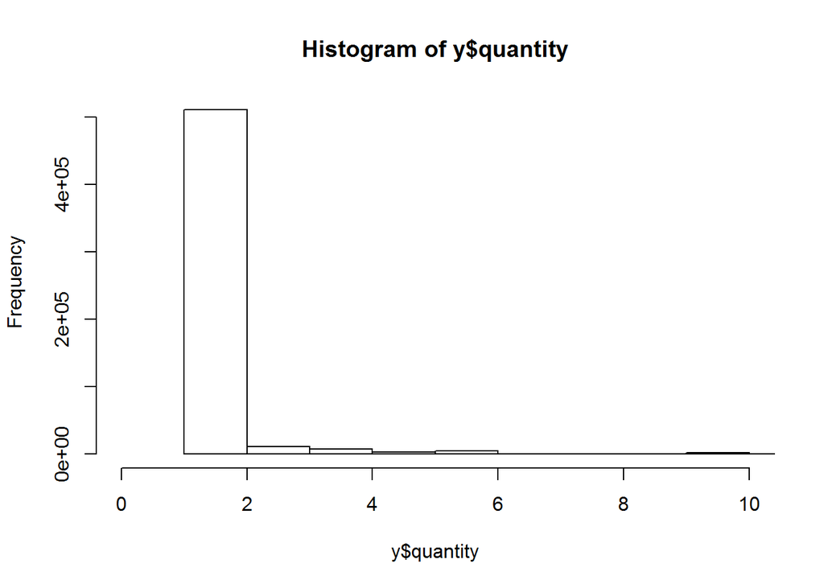

Podemos ver de cara uma distribuicao assimetrica a direita, tambem podemos ver que quase todas compras sao compostas de um itens.

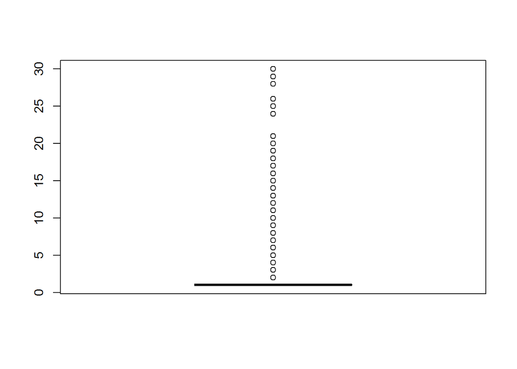

Vemos no primeiro plot do Boxplot que temos muitos outliers fora da maior concentraçao de dados,ou seja, alguns contra exemplos da maioria onde muito itens foram comprados e podendo chegar ate perto de 30 itens em uma compra.

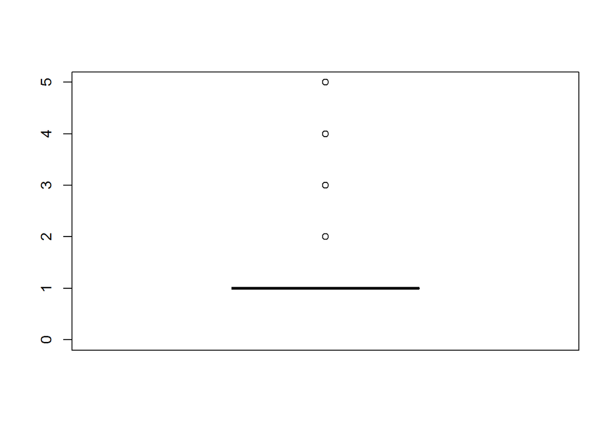

```
##    Min. 1st Qu.  Median    Mean 3rd Qu.    Max.
##   1.000   1.000   1.000   1.375   1.000  30.000
```

Aproximando o Boxplot e com ajuda do sumario, podemos ver como o valor dos itens esta com uma concentraçao quase que total em compreas de um iten so. Devido a essa assimetria (causada pelos outliers), devemos confiar na mediana: um item comprado por compra.

Agora vamos partir para a analise dos poucos campos que podem ser analisados dos cliques dos usuarios:

Devido a probelmas de memoria para rodar os 1.6GB dos dados de click, foi selecionada apenas uma amostra de 2 milhoes de entradas do banco de dados.

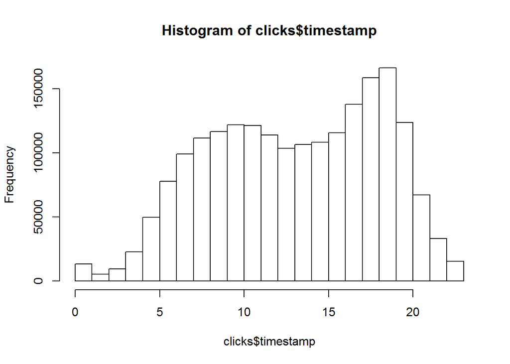

Seguindo o encontrado para as compras, percebemos que das 7 da manha as 7 da noite é o periodo principal de compras, tendo como destaque 5 e 6 da tarde como hora mais propença a compras. Podendo assim, tracar um paralelo que o comportamento de clicks esta relacionados a efetivar compra.

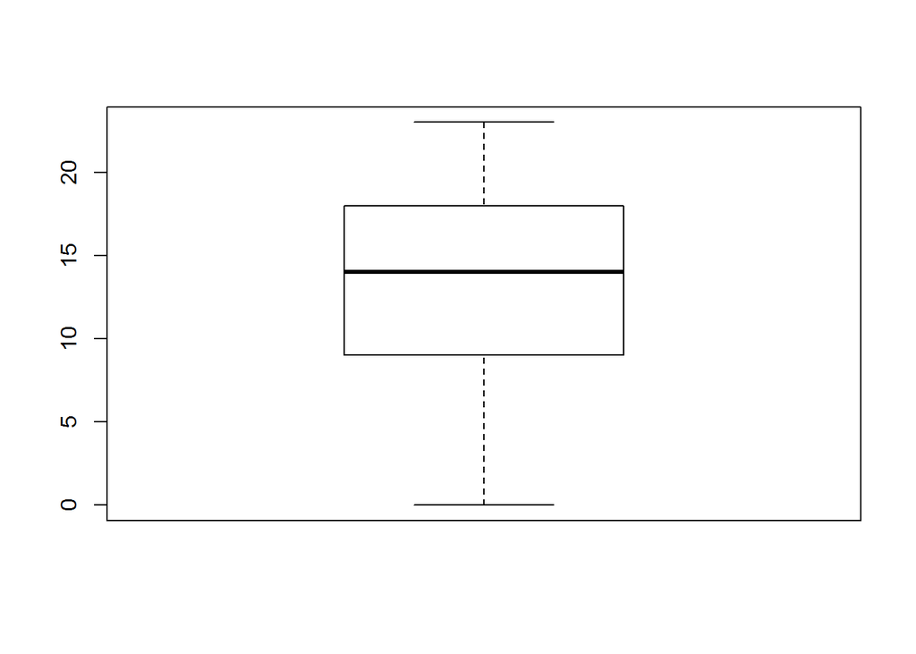

```
##    Min. 1st Qu.  Median    Mean 3rd Qu.    Max.
##    0.00    9.00   14.00   13.53   18.00   23.00
```

Tentamos analisar tambem as categorias e tracar um paralelo do horario dos clicks a uma categoria ou se uma sessao (compra) teve mais de uma categoria, mas o campo é representado so por zeros (que segundo o guia indica “categoria nao identificada”).

*ESTRATEGIA* 1) RANKING Nossa estrategia se baseava em rankear itens usando uma formula que ponderava a vendabilidade (numero de vendas de um item / numero de clicks nesse mesmo item) e o preco proporcional de um item (Media de preco mais vendida/ valor do produto). Nossa tabela de rankin era entao ordenada por categoria (primeiro) e pelo resultado dessa formula (segundo). Devido ao tamanho dos dados, o Ranking contabilizou apenas as categorias que se encontravam entre 1 e 12 mais a S (special offer).

```r
#preparando o rankin

colnames(itemsRankin) = c("session","category","vendability")
itemsRankin["price"] <- 0
itemsRankin["recomendador"] <- 0
count = 1
for(i in 1:nrow(itemsRankin)){
  print(i)
  if(itemsRankin[i,1] > itemPrices[count,1]){
    inc(count)
  }
  if(itemsRankin[i,1] == itemPrices[count,1]){
    itemsRankin[i,4] = itemPrices[count,2]
    inc(count)
  }else{
    itemsRankin[i,4] = 0
  }
}

inc <- function(x)
{
  eval.parent(substitute(x <- x + 1))
}

#Somando o ranking
valor = 0
for(i in 1:nrow(itemsRankin)){
  print(i)
  valor = itemsRankin[i,3] + (1046/itemsRankin[i,4])

  if(!is.infinite(valor)){
    itemsRankin[i,5] = valor
  }else{
    itemsRankin[i,5] = 0
  }
}

x = itemsRankin[order(itemsRankin$category,-(itemsRankin$recomendador) ),]
```

2)PREDICAO Inicialmente fizemos um merge entre a tabela de clicks e a de compra, para saber quais clicks resultaram em compras

```r
compra = intersect(clicksLim$session,buysLim$session)
clicksLim["buy"] <- 0
clicksLim$buy <- clicksLim$session %in% compra
```

Nosso primeiro passo foi gerar uma Arvore de predicao (usando a biblioteca C50 em R) para gerar uma tabela onde um click fosse considerado como um comprador em potencial ou nao.

```r
library("C50")

#gerando o modelo
clicksLim$X <- NULL
fac_buy <- factor(clicksLim$buy)
buy_model <- C5.0(clicksLim[,-5], fac_buy)
summary(buy_model)

#doismilhoes.csv usa apenas as 2M primeiras linhas do dataset que se encontram nas categoria 1 ate 12 ou S
teste <- read.table("doismilhoes.csv", nrows = 2000000,header = FALSE, sep = " ")
colnames(teste) = c("session","timestamp","itenid","category")
teste$timestamp = as.numeric(as.character(substring(teste$timestamp, 12, 13)))
teste$buyPrev <- FALSE

p <- predict( buy_model, teste, type="class" )
c = data.frame(teste$session,teste$timestamp,teste$itenid,teste$category,p)
```

Para os compradores em potencial, mediante a categoria do seu click, recomendavamos 5 itens mais relevantes da tabela de rankeamento mediante a formula (citada anteriormente).

```r
predicaoDeBuys["itensRec"] <- 0
#nao pegar a tabela de predicao de buys de uma vez
for(i in 1:nrow(predicaoDeBuys)){
  if(predicaoDeBuys[i,5]==TRUE){

    for(k in 1:nrow(PegandoRankin)){
      if(predicaoDeBuys[i,4] = PegandoRankin[k,3]){
        predicaoDeBuys[i,6] = paste(PegandoRankin[k,2],PegandoRankin[(k+1),2],PegandoRankin[(k+2),3],PegandoRankin[(k+3),3],PegandoRankin[(k+4),3])
      }
    }
  }
}
```